# hab3

Lukáš Hejtmánek

Wed Jul 08 18:55:24 2020

## Summative heatmaps

### females

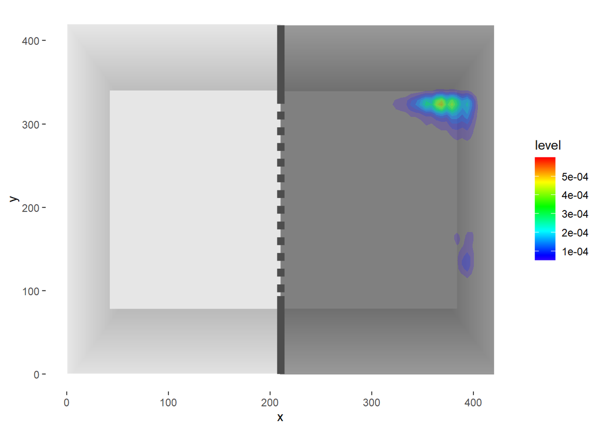

### males

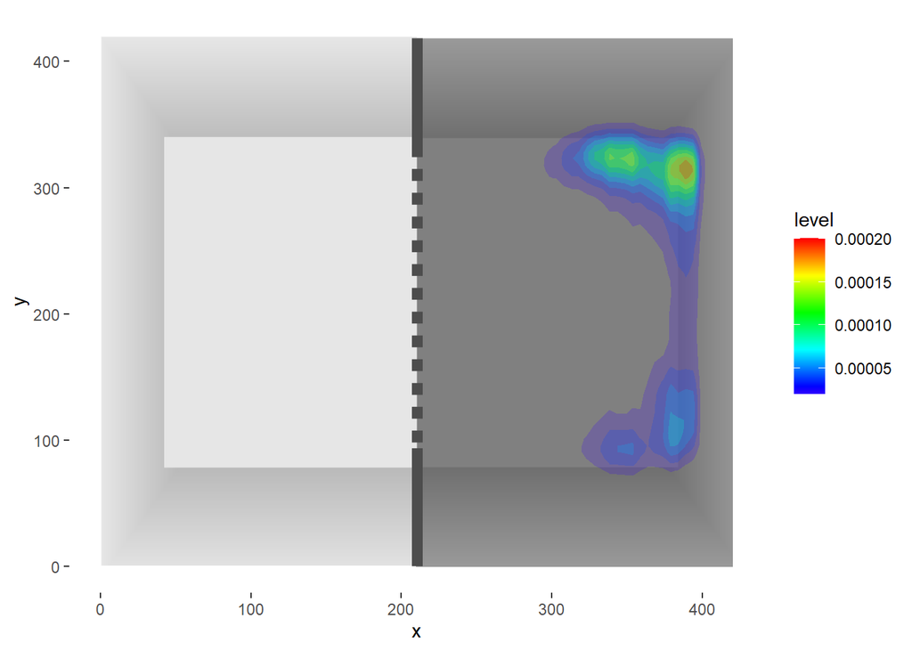

### Individual animals

animal_1

Animal:

animal_1

Distance:

45557.27

Time in left zone:

50.97

Time in right zone:

835.75

Time in central zone:

12.29

Crosses to the right:

8

Crosses to the left:

8

Number of freezes:

2

Total freeze time:

8.86

Freeze time ratio:

0.01

Animal:

animal_1

Distance:

16040.62

Time in left zone:

NA

Time in right zone:

899.16

Time in central zone:

NA

Crosses to the right:

0

Crosses to the left:

0

Number of freezes:

19

Total freeze time:

192.2

Freeze time ratio:

0.21

animal_10

Animal:

animal_10

Distance:

18695.49

Time in left zone:

NA

Time in right zone:

899.94

Time in central zone:

NA

Crosses to the right:

0

Crosses to the left:

0

Number of freezes:

23

Total freeze time:

203.5

Freeze time ratio:

0.23

Animal:

animal_10

Distance:

12448

Time in left zone:

NA

Time in right zone:

899.19

Time in central zone:

NA

Crosses to the right:

0

Crosses to the left:

0

Number of freezes:

31

Total freeze time:

217.42

Freeze time ratio:

0.24

animal_2

Animal:

animal_2

Distance:

21058.43

Time in left zone:

NA

Time in right zone:

899.59

Time in central zone:

0.33

Crosses to the right:

0

Crosses to the left:

0

Number of freezes:

20

Total freeze time:

185.42

Freeze time ratio:

0.21

Animal:

animal_2

Distance:

19189.8

Time in left zone:

NA

Time in right zone:

899.6

Time in central zone:

NA

Crosses to the right:

0

Crosses to the left:

0

Number of freezes:

18

Total freeze time:

172.01

Freeze time ratio:

0.19

animal_3

Animal:

animal_3

Distance:

16959.55

Time in left zone:

NA

Time in right zone:

875.51

Time in central zone:

NA

Crosses to the right:

0

Crosses to the left:

0

Number of freezes:

20

Total freeze time:

169.45

Freeze time ratio:

0.19

Animal:

animal_3

Distance:

4537.26

Time in left zone:

NA

Time in right zone:

899.36

Time in central zone:

NA

Crosses to the right:

0

Crosses to the left:

0

Number of freezes:

42

Total freeze time:

540.19

Freeze time ratio:

0.6

animal_4

Animal:

animal_4

Distance:

10268.26

Time in left zone:

NA

Time in right zone:

899.59

Time in central zone:

NA

Crosses to the right:

0

Crosses to the left:

0

Number of freezes:

32

Total freeze time:

398.36

Freeze time ratio:

0.44

Animal:

animal_4

Distance:

29467.54

Time in left zone:

NA

Time in right zone:

898.41

Time in central zone:

0.78

Crosses to the right:

0

Crosses to the left:

0

Number of freezes:

3

Total freeze time:

9.41

Freeze time ratio:

0.01

animal_5

Animal:

animal_5

Distance:

12215.72

Time in left zone:

NA

Time in right zone:

895.91

Time in central zone:

NA

Crosses to the right:

0

Crosses to the left:

0

Number of freezes:

27

Total freeze time:

247.17

Freeze time ratio:

0.28

Animal:

animal_5

Distance:

15117.16

Time in left zone:

NA

Time in right zone:

899.9

Time in central zone:

NA

Crosses to the right:

0

Crosses to the left:

0

Number of freezes:

20

Total freeze time:

188.48

Freeze time ratio:

0.21

animal_6

Animal:

animal_6

Distance:

9927.29

Time in left zone:

NA

Time in right zone:

895.78

Time in central zone:

NA

Crosses to the right:

0

Crosses to the left:

0

Number of freezes:

24

Total freeze time:

441.72

Freeze time ratio:

0.49

Animal:

animal_6

Distance:

19379.16

Time in left zone:

NA

Time in right zone:

895.38

Time in central zone:

NA

Crosses to the right:

0

Crosses to the left:

0

Number of freezes:

13

Total freeze time:

138.87

Freeze time ratio:

0.16

animal_7

Animal:

animal_7

Distance:

22307.14

Time in left zone:

NA

Time in right zone:

898.98

Time in central zone:

NA

Crosses to the right:

0

Crosses to the left:

0

Number of freezes:

23

Total freeze time:

147.76

Freeze time ratio:

0.16

Animal:

animal_7

Distance:

21422.33

Time in left zone:

NA

Time in right zone:

884.31

Time in central zone:

NA

Crosses to the right:

0

Crosses to the left:

0

Number of freezes:

13

Total freeze time:

113.23

Freeze time ratio:

0.13

animal_8

Animal:

animal_8

Distance:

17140

Time in left zone:

NA

Time in right zone:

892.16

Time in central zone:

NA

Crosses to the right:

0

Crosses to the left:

0

Number of freezes:

22

Total freeze time:

185.14

Freeze time ratio:

0.21

Animal:

animal_8

Distance:

19351.41

Time in left zone:

NA

Time in right zone:

893.09

Time in central zone:

NA

Crosses to the right:

0

Crosses to the left:

0

Number of freezes:

14

Total freeze time:

140.78

Freeze time ratio:

0.16

animal_9

Animal:

animal_9

Distance:

15587.63

Time in left zone:

NA

Time in right zone:

892.84

Time in central zone:

NA

Crosses to the right:

0

Crosses to the left:

0

Number of freezes:

33

Total freeze time:

242.58

Freeze time ratio:

0.27

Animal:

animal_9

Distance:

21520.94

Time in left zone:

NA

Time in right zone:

890.83

Time in central zone:

NA

Crosses to the right:

0

Crosses to the left:

0

Number of freezes:

15

Total freeze time:

74.16

Freeze time ratio:

0.08

## Summary statistics

#### females

Animal:

Distance:

18971.68

Time in left zone:

50.97

Time in right zone:

888.61

Time in central zone:

6.31

Crosses to the right:

0.8

Crosses to the left:

0.8

Number of freezes:

22.6

Total freeze time:

223

Freeze time ratio:

0.25

#### males

Animal:

Distance:

17847.42

Time in left zone:

NaN

Time in right zone:

895.92

Time in central zone:

0.78

Crosses to the right:

0

Crosses to the left:

0

Number of freezes:

18.8

Total freeze time:

178.68

Freeze time ratio:

0.2